# Estudio variabilidad estructural proteica

30/01/2016

## Conjuntos de proteinas

### Conjunto teorico

190 mutantes de 1awj (77 sitios) simuladas con el modelo mutacional LFENM con ANM *R0* = 12 y *Fmax* = 2 (solo para LFENM). Para determinar que sitios mutar, se alineo 1awj con cada una de las proteinas del conjunto, se obtuvieron los indices de los sitios alineados pero mutados y se simularon 10 mutantes por cada par de proteinas, obteniendose un total de 190 mutantes. Luego, para el analisis, se tomaron como alineados los sitios alineados de 1awj para cada par de proteinas.

### Conjunto experimental

19 proteinas de la familia de sh3. Las proteinas tienen un promedio de identidad secuencial de 27%. El core del alineamiento de la familia es de 45 sitios.

La caracterizacion del conjunto experimental se muestra a continuacion:

```
##     pdbid nsites naligned identity       MSD
## 1    1shg     57       56 33.92857  6.680703
## 2   1shfa     59       58 36.20690  6.873864
## 3    2src     62       57 29.82456  5.743153
## 4   1qcfa     65       60 28.33333 14.516316
## 5   1lcka     54       53 32.07547  6.139546
## 6   1qlya     58       58 46.55172 10.747924
## 7   1bbza     58       56 26.78571  7.338489
## 8  1gria1     50       50 24.00000  6.287323
## 9   1gbra     74       65 20.00000 51.588423
## 10  1cska     57       56 23.21429  7.706739
## 11  1ckaa     56       55 27.27273  6.760650
## 12  1sema     58       58 27.58621  7.455519
## 13 1gria2     61       58 27.58621  7.047285
## 14  1ycsb     63       60 23.33333 11.572007
## 15   2hsp     71       62 25.80645  8.616786
## 16   1ark     60       57 19.29825  6.722685
## 17  1aoja     60       55 25.45455  7.437899
## 18   1pht     83       56 21.42857 11.949796
## 19   1bb9     83       66 18.18182 53.976834
```

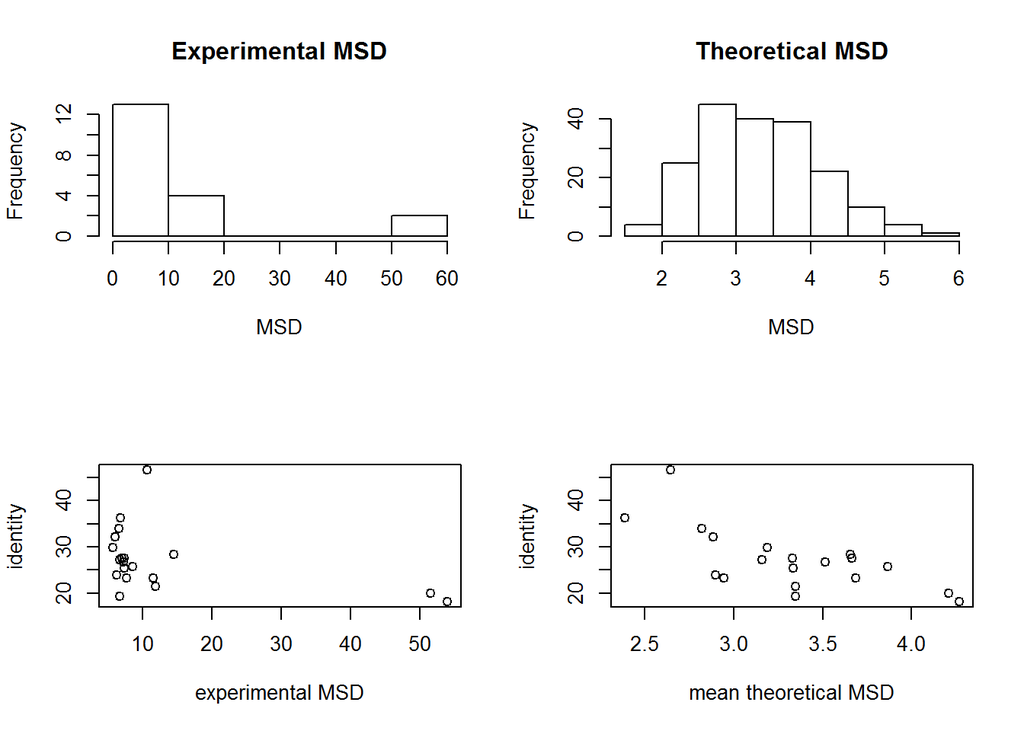

## Comparaciones

### RHO y AUC

Las distribuciones de *auc* y *rho* para cada conjunto se muestran a continuacion (azul= teorico, rojo = experimental)

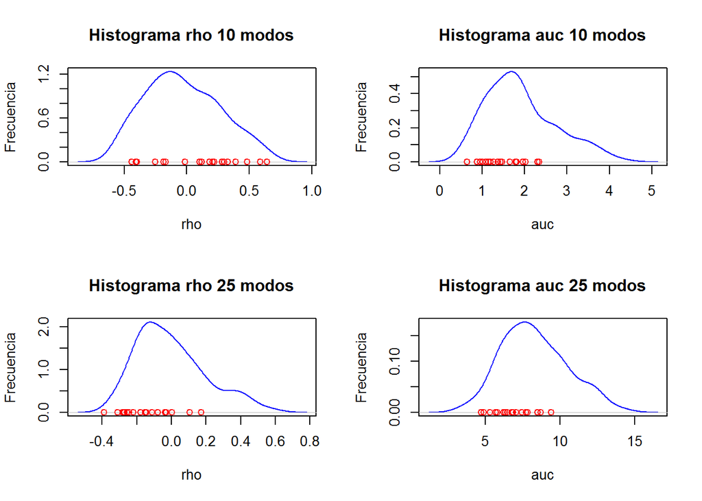

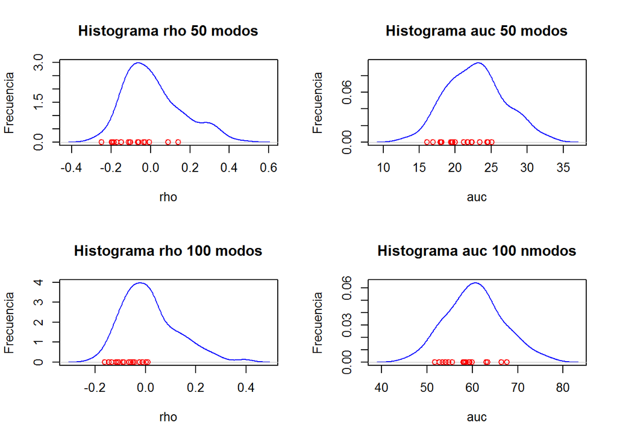

## Pn y Qn

Las distribuciones de *Pn* y *Qn* de los conjuntos son las siguientes:

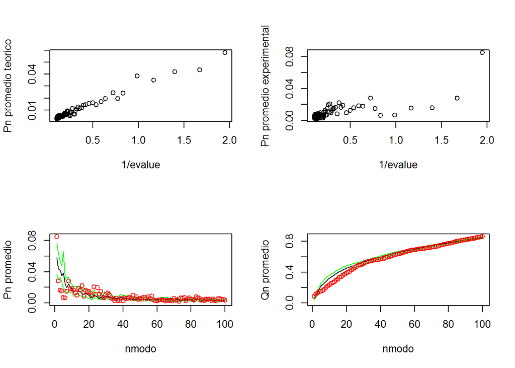

Negro: Teorico Rojo: Experimental Verdes: Cuartiles 0.05 y 0.95 de 10 grupos de 19 mutantes teoricas.